# Step 3 - Prepping the BZA Data

## Reducing the Data Set

```r
#dropping prodcution data Raselstein variables
var.wa <- df_BZA %>%
  dplyr::select(starts_with("WA_")) %>%
  names()
df_BZA <- df_BZA %>%
  dplyr::select(-var.wa)
#Deleting redundant indexes
var.index.dup <- df_BZA %>%
  dplyr::select(SCHMELZ_NR, contains("IDENT"), contains("_NR"), contains("BRAMMEN"), contains("UUID"), contains("NAME"), contains("SID")) %>%
  names()
df_BZA <- df_BZA %>%
  dplyr::select(-var.index.dup)
#Drop time stamps
var.ts <- df_BZA %>%
  dplyr::select(contains("ZEITPUNKT"), contains("ZEITSEL"), contains("DATUM"), contains("TIME"), contains("SEQ")) %>%
  names()
df_BZA <- df_BZA %>%
  dplyr::select(-var.ts)
#Remove Irrelevant Variables (Table from Dr. Eberle)
var.irv <- c("basePID", "ImportFlag", "A1", "Weight")
df_BZA <- df_BZA %>%
  dplyr::select(-var.irv)
```

```r
#Convert to long format and check availability and missing patters
df_BZA_long <- df_BZA %>%
  tidyr::gather(key=length_attr, value=measurement, -c(CoilID, lTileID))
```

#### Computing Descriptives

Variable Descriptives

| length_attr | count | unique | na | N |
| --- | --- | --- | --- | --- |
| BA_ENDWALZ_GESCHW | 33811 | 62 | 0 | 33811 |
| BA_ENDWALZ_TEMP | 33811 | 30 | 0 | 33811 |
| BA_VORBAND_DICKE | 33811 | 101 | 0 | 33811 |
| Class.14 | 33811 | 17 | 0 | 33811 |
| Class.15 | 33811 | 21 | 0 | 33811 |
| Class.4 | 33811 | 29 | 0 | 33811 |
| HASPEL_T_1 | 33811 | 16 | 0 | 33811 |
| Length | 33811 | 197 | 0 | 33811 |
| Material | 33811 | 1 | 0 | 33811 |
| Plant | 33811 | 1 | 0 | 33811 |
| TH_STM_IST | 33811 | 2 | 0 | 33811 |
| Thick | 33811 | 3 | 0 | 33811 |
| WB_BREITE | 33811 | 4 | 0 | 33811 |
| WB_DICKE | 33811 | 3 | 0 | 33811 |
| WB_KZ_KANTENERWAERMUNG | 33811 | 2 | 0 | 33811 |
| WB_STAHLWERK | 33811 | 2 | 0 | 33811 |
| WB_WERK | 33811 | 1 | 0 | 33811 |
| Width | 33811 | 3 | 0 | 33811 |

Multiple constant variables can be observed in the data. These variables are dropped below.

```r
var.BZA.const <- df_BZA_desc%>%
  dplyr::filter(unique == 1) %>%
  dplyr::select(length_attr) %>%
  unlist() %>%
  as.character()

df_BZA_long <- df_BZA_long %>%
  dplyr::filter(!length_attr %in% var.BZA.const)
```

### Checking Variable Distributions

```r
var.BZA.bin <- df_BZA_desc%>%
  dplyr::filter(unique <= 3) %>%
  dplyr::select(length_attr) %>%
  unlist()

df_BZA_bin_long <- df_BZA_long %>%
  dplyr::filter(length_attr %in% var.BZA.bin)
```

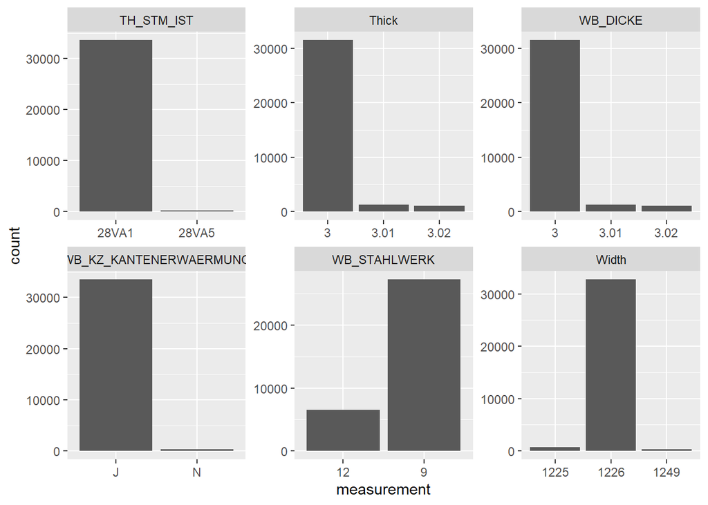

These variables don’t seem to be binary due to some sort of masking. There is very little variability in TH_STM_IST and VB_KZ… .

```r
#Back to wide form
df_BZA <- df_BZA_long %>%
  tidyr::spread(key = length_attr, value = measurement)
```

```r
#Dropping obs not tied to TH_STM_IST$28VA1
df_BZA <- df_BZA %>%
  dplyr::filter(TH_STM_IST == "28VA1")

#Sending most charvars to numeric (Excluding TH_STM_IST and WB_KZ_KANTENRWAERMUNG)
df_BZA <- df_BZA %>%
  dplyr::select(-c(TH_STM_IST, WB_KZ_KANTENERWAERMUNG)) %>%
  dplyr::mutate_if(is.character, as.numeric) %>%
  dplyr::bind_cols(df_BZA[,c("TH_STM_IST", "WB_KZ_KANTENERWAERMUNG")])
```

```
## `mutate_if()` ignored the following grouping variables:
## Column `CoilID`
```

```r
#Dropping piece related vars
df_BZA <- df_BZA %>%
  dplyr::select(-starts_with("WB_"), -starts_with("BA_"), -c(TH_STM_IST, WB_KZ_KANTENERWAERMUNG), -Width, -Thick, -Length, -HASPEL_T_1)
```

## Saving Data, Validating Data, and Final Comments

### Saving Data

Data was saved before validation to ensure accurate comparisons.

```r
#Saving Final Output data
save(list=ls(pattern="defects"), file="../anna_data/anna_defects_1.Rdata")
save(df_BZA, file="../anna_data/anna_df_BZA_1.Rdata")
```

### Validating Data

All files match excluding df_BZA, which are notably different. It is worth noting that, when comparing the data available on nextcloud as produced by Prof. Wilhelm with the output of the orginal code file, the data also does not match. The non-matching entries are not mutually exclusive between the three files: mine, Prof. Wilhelms, and that which is produced by the original code file.